# Pitch_Location_Analysis

2022-07-18

# Aaron Judge and Giancarlo Stanton

Statcast is a state-of-the-art tracking system that uses high-resolution cameras and radar equipment to measure the precise location and movement of baseballs and baseball players. we’re going to wrangle, analyze, and visualize Statcast data to compare Mr. Judge and Mr Stanton

Batted ball events-which is any batted ball that produces a result. This includes outs, hits, and errors. Lets find the counts of batted ball events for each player in 2017

JUDGE COUNTS

| events | n |
| --- | --- |
| strikeout | 207 |
| field_out | 146 |
| walk | 116 |
| single | 75 |
| home_run | 52 |
| double | 24 |
| grounded_into_double_play | 15 |
| force_out | 11 |
| intent_walk | 11 |
| hit_by_pitch | 5 |
| field_error | 4 |
| fielders_choice_out | 4 |
| sac_fly | 4 |
| triple | 3 |
| strikeout_double_play | 1 |

STANTON COUNTS

| events | n |
| --- | --- |
| field_out | 239 |
| strikeout | 161 |
| single | 77 |
| walk | 72 |
| home_run | 59 |
| double | 32 |
| grounded_into_double_play | 13 |
| intent_walk | 13 |
| force_out | 7 |
| hit_by_pitch | 7 |
| field_error | 5 |
| sac_fly | 3 |
| fielders_choice_out | 2 |
| strikeout_double_play | 2 |
| pickoff_1b | 1 |

# Analysing Home Runs

## Launch Speed vs Launch Angle

Two of the most groundbreaking Statcast metrics are launch angle and exit velocity:

Launch angle: the vertical angle at which the ball leaves a player’s bat Exit velocity: the speed of the baseball as it comes off the bat

Let’s look at exit velocity vs. launch angle and let’s focus on home runs only (2015-2017). The first two plots show data points. The second two show smoothed contours to represent density.

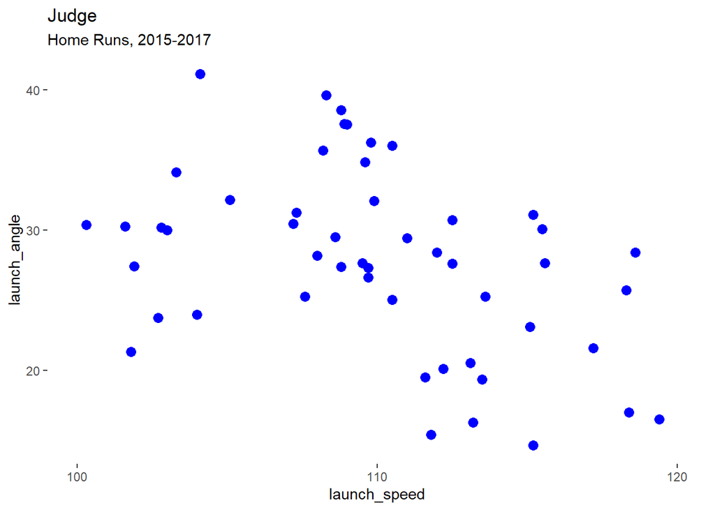

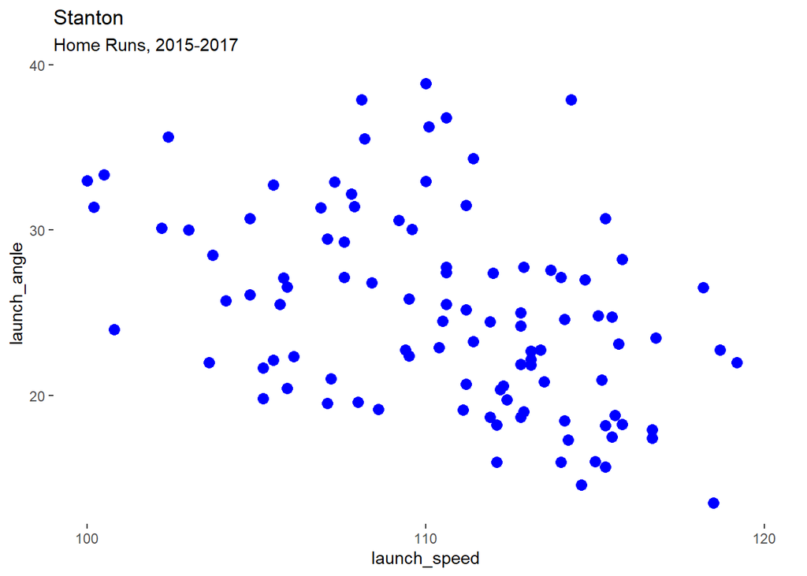

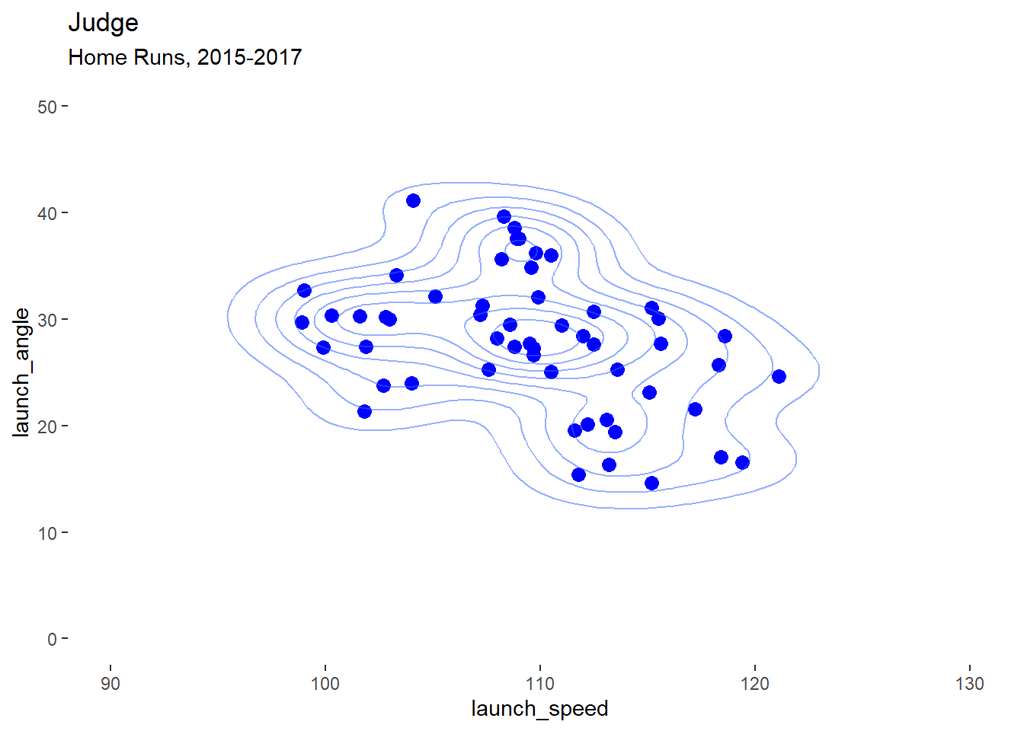

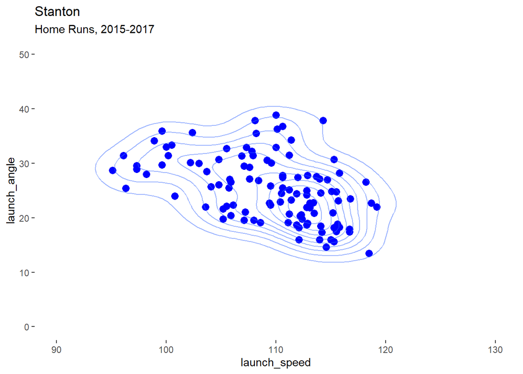

## Home Runs by Pitch Velocity

Lets compare Stanton and Judge’s home runs in terms of pitch velocity.

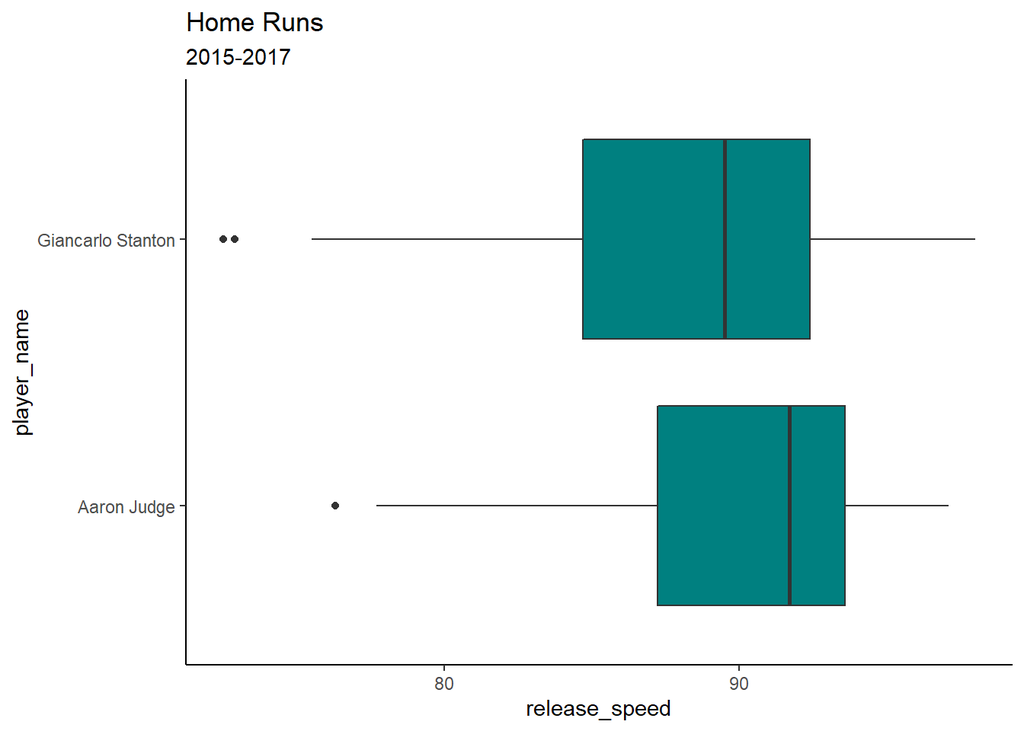

## Home Runs by Pitch Location

Statcast tracks the zone the pitch is in when it crosses the plate.We can plot this using a 2D histogram.

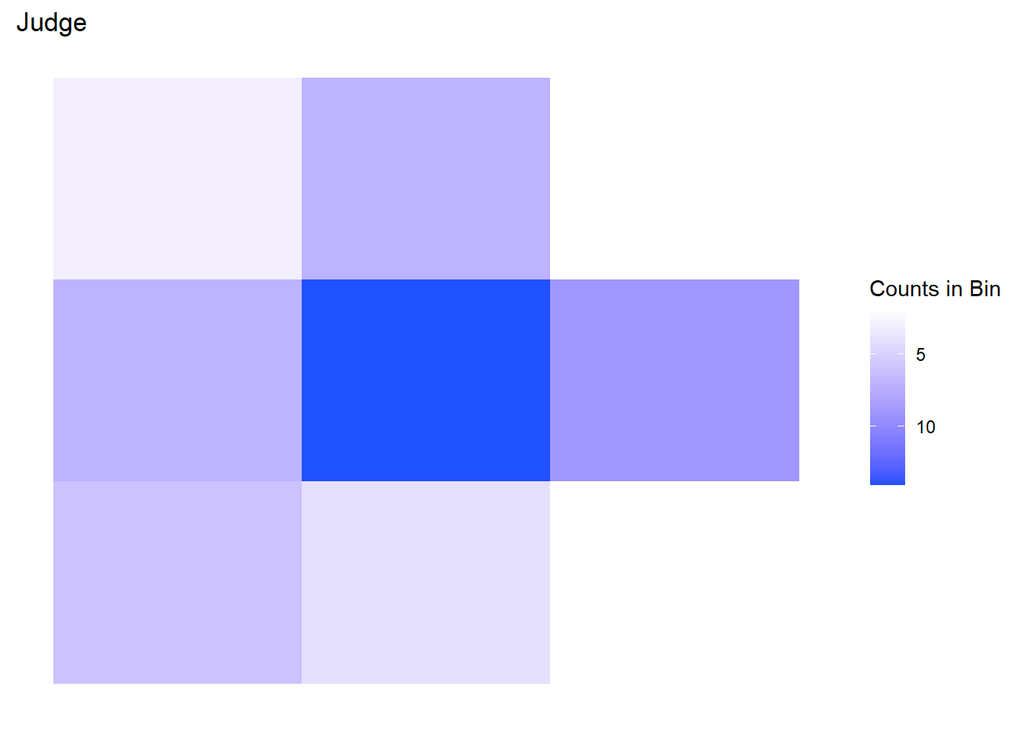

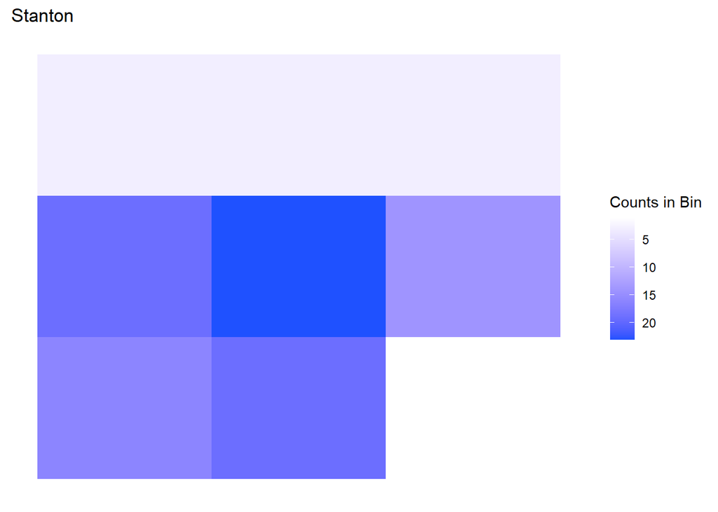